# DS養成講座 Jリーグ観客動員数を予測せよ！

Shinji KAWASOE

Data : 2017-11-24

# 1 概要

コンペの内容  
https://deepanalytics.jp/compe/27

本コンテストでは、2012年～2014年シーズン前半までのデータを使って、  
「2014年後半戦J1,J2全試合の観客動員数を予測するモデル」  
を作成していただきます。

# 2 取り組み内容

## 2.1 モデル作成用のカラム

```r
## 使用ライブラリ
library(tidyverse)
library(knitr)

param <- c("capa", "pre_rank.home", "pre_rank.away", "media", "section", "home_team", "away_team","hour","week","rain")
explain <- c("スタジアムの収容人数", "前節のランキング(home)","前節のランキング(away)", "tv局数", "節", "ホームチーム", "アウェイチーム", "開始時刻", "1(土日祝)、0(平日)", "1(雨)、0(雨以外)")
cols <- data.frame(Parameter=param, Explain=explain)

kable(cols)
```

| Parameter | Explain |
| --- | --- |
| capa | スタジアムの収容人数 |
| pre_rank.home | 前節のランキング(home) |
| pre_rank.away | 前節のランキング(away) |
| media | tv局数 |
| section | 節 |
| home_team | ホームチーム |
| away_team | アウェイチーム |
| hour | 開始時刻 |
| week | 1(土日祝)、0(平日) |
| rain | 1(雨)、0(雨以外) |

## 2.2 ポイントとその履歴

2017.11.24

結果 3,541.71704

- home, awayを分けていたレコードをマージする。
- stargeを分けない。
- HoledOutを期間からランダムに変更した。

2017.11.22

結果 3,588.19272

- stageでデータとモデルを分ける。

2017.11.21

結果 3,581.93207

- tv局数、節、ホームチーム、アウェイチーム、開始時刻、土日祝、雨のパラメータを追加した。

2017.11.20

結果 6,048.90214

- 追加データを加える。
- 勝点と前節ランキングを算出する。

2017.11.10

結果 6,071.35336

- HoldOutを2012-2013年を構築データとし、2014年を検証データで行なう。
- R Markdownを作成する。

# 3 データ加工

```r
## データ読込(結合したデータ)
train<-read.csv("../data/train_new.csv", #読込ファイル
                header=TRUE, #読込データのヘッダー有無
                stringsAsFactors=FALSE #文字列の読込時の型指定(character)
)
test<-read.csv("../data/test_new.csv",
               header=TRUE,
               stringsAsFactors=FALSE)
```

## 3.1 データ加工を全データに実施するため、trainとtestを結合する。

```r
test$y <- NA
combi <- rbind(train,test)

## 今は使わないカラムを減らして、少し見やすくする。後で使うかも。
combi <- combi %>%
    dplyr::select(-(home_01:home_11),-(away_01:away_11))
```

## 3.2 開催節を分割する。

時系列データとして扱い易いように変更する。  
開催節(match)を節(section)と連番(seq)に分ける。

```r
## 節を加工
combi <- combi %>%
    dplyr::mutate(match = purrr::map(match, stringi::stri_trans_nfkc)) %>%
    dplyr::mutate(match = str_replace_all(match, pattern = "[第日]", replacement = "")) %>%
    tidyr::separate(match, into = c('section','seq'), sep="節") %>%
    dplyr::mutate(section = as.numeric(section) ,
                  seq = as.numeric(seq))
```

## 3.3 勝点とランキングを考える。

### 3.3.1 勝点を算出する。

- 勝点は各節でTeam単位に出力されるため、home, awayの両方を計算する必要がある。
- 自分と相手のscoreを比較して、勝点(3,1,0)を算出する。

```r
## home, awayでレコードを分ける
combi_split <- combi %>%
    tidyr::gather(`home`,`away`, key="type", value="team") %>%
    dplyr::mutate(my_score = if_else(type=="home", home_score, away_score),
                  opponent_score = if_else(type=="home", away_score, home_score))

## 勝点の算出
combi_split <- combi_split %>%
    dplyr::mutate(victory_point = 0,
                  victory_point = if_else(my_score > opponent_score, 3, victory_point),
                  victory_point = if_else(my_score == opponent_score, 1, victory_point))
```

### 3.3.2 得失点を算出する。

- チームごと(group_by)に、自分と相手のscoreを減算して、その結果を累積(Cumulative)する。
- 勝点の累積を算出する。

```r
## 得失点、勝点の累積を算出
combi_point <- combi_split %>%
    dplyr::group_by(year, team) %>%
    dplyr::arrange(year,section,seq) %>%
    dplyr::mutate(cum_vp = cumsum(victory_point)) %>%
    dplyr::mutate(cum_score = cumsum(my_score - opponent_score)) %>%
    dplyr::ungroup(.)
```

### 3.3.3 順位を算出する。

- 節で切りTeamの全ての勝点と得失点でrankingを取る。
- rank : 節単位のランキング
- desc_rank : 逆順でのランキング(下位が上位)
- pre_rank : 前節のランキング

```r
combi_rank <- combi_point %>%
    dplyr::group_by(year, section, stage) %>%
    dplyr::mutate(rank = min_rank(cum_vp)) %>%
    dplyr::mutate(desc_rank = if_else(stage == "Ｊ１", 34 - rank, 42 - rank)) %>%
    dplyr::ungroup(.)

combi_pre_rank <- combi_rank %>%
    dplyr::group_by(year, team) %>%
    dplyr::mutate(pre_rank = lag(rank)) %>%
    dplyr::ungroup(.) %>%
    dplyr::mutate(pre_rank = ifelse(is.na(pre_rank),0, pre_rank))

## pre_rankにNAが含まれている。
## 後述する分析結果より、pre_rankがyに対して負の相関あり？と考えて、0を投入する。

combi_pre_rank %>%
    dplyr::filter(team == "鹿島アントラーズ") %>%
    glimpse
```

```
## Observations: 102
## Variables: 30
## $ id             <int> 13994, 14003, 14013, 14028, 14036, 14040, 14052...
## $ y              <int> 18250, 19010, 14349, 22126, 23507, 19279, 12110...
## $ year           <int> 2012, 2012, 2012, 2012, 2012, 2012, 2012, 2012,...
## $ stage          <chr> "Ｊ１", "Ｊ１", "Ｊ１", "Ｊ１", "Ｊ１", "Ｊ１", "Ｊ１", "Ｊ１",...
## $ section        <dbl> 1, 2, 3, 4, 5, 6, 7, 8, 9, 10, 11, 12, 13, 14, ...
## $ seq            <dbl> 1, 1, 1, 1, 1, 1, 1, 1, 1, 1, 1, 1, 2, 1, 1, 1,...
## $ gameday        <chr> "03/10(土)", "03/17(土)", "03/24(土)", "03/31(土)",...
## $ time           <chr> "14:04", "14:04", "13:04", "19:03", "17:04", "1...
## $ stadium        <chr> "ユアテックスタジアム仙台", "県立カシマサッカースタジアム", "エディオンスタジアム広島...
## $ tv             <chr> "スカパー／ｅ２／スカパー光／ＮＨＫ総合", "スカパー／ｅ２／スカパー光／ＮＨＫ水戸", "...
## $ home_score     <int> 1, 0, 2, 0, 1, 1, 3, 5, 3, 0, 3, 7, 1, 2, 1, 1,...
## $ away_score     <int> 0, 1, 0, 0, 3, 2, 2, 0, 0, 0, 0, 0, 2, 3, 1, 1,...
## $ weather        <chr> "雨", "雨", "曇時々晴", "曇のち雨", "晴のち曇", "雨", "曇時々晴", ...
```

[output cut: 17 more lines]

```r
## 試合単位にマージ
home_combi <- combi_pre_rank %>%
    dplyr::filter(type == "home") %>%
    dplyr::select(c(id, victory_point, cum_vp, cum_score, rank, desc_rank, pre_rank))

away_combi <- combi_pre_rank %>%
    dplyr::filter(type == "away") %>%
    dplyr::select(c(id, victory_point, cum_vp, cum_score, rank, desc_rank, pre_rank))

combi_ranking <- combi %>%
    dplyr::left_join(home_combi, by="id") %>%
    dplyr::rename(victory_point.home = victory_point,
                  cum_vp.home = cum_vp,
                  cum_score.home =cum_score,
                  rank.home = rank,
                  desc_rank.home = desc_rank,
                  pre_rank.home = pre_rank) %>%
    dplyr::left_join(away_combi, by="id") %>%
    dplyr::rename(victory_point.away = victory_point,
                  cum_vp.away = cum_vp,
                  cum_score.away =cum_score,
                  rank.away = rank,
                  desc_rank.away = desc_rank,
                  pre_rank.away = pre_rank)
```

## 3.4 その他の加工

### 3.4.1 テレビ局の数の導出

局数が増加すると動員数も増加している傾向が見られる。

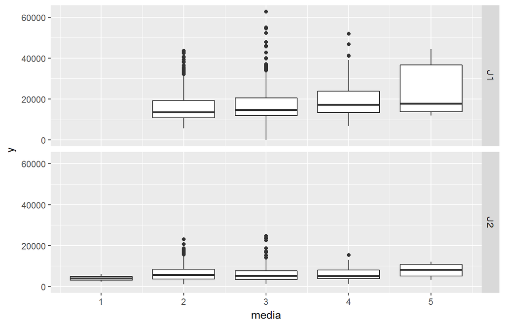

```r
combi_tv <- combi_ranking %>%
    dplyr::mutate(media = str_count(tv,"／") + 1)

combi_tv %>%
    ggplot(mapping = aes(x = media, y = y)) +
    geom_boxplot(aes(group = cut_width(media,1))) +
    facet_grid(stage ~ .)
```

### 3.4.2 開始時間

todo 翌日休みフラグ もう少し考えが必要

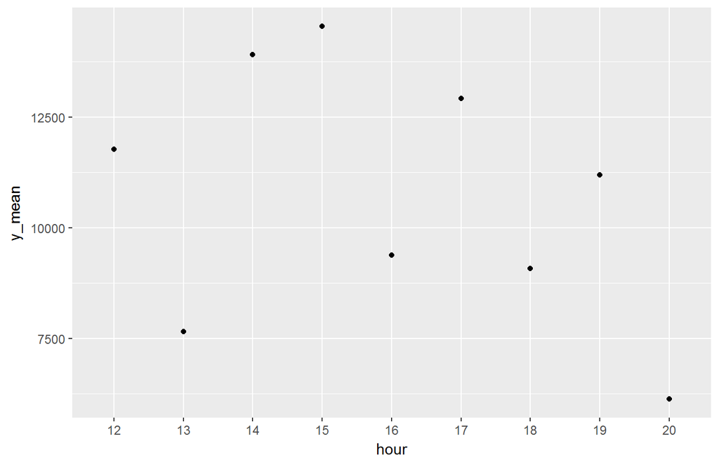

```r
combi_time <- combi_tv %>%
    dplyr::mutate(hour = str_sub(time, 1,2)) %>%
    dplyr::mutate(week = ifelse(str_detect(gameday,"[土日祝]"), 1, 0))

combi_time %>%
    dplyr::group_by(hour) %>%
    dplyr::summarise(y_mean = mean(y, na.rm=TRUE)) %>%
    dplyr::ungroup(.) %>%
    ggplot(mapping = aes(x = hour, y = y_mean)) + geom_point()
```

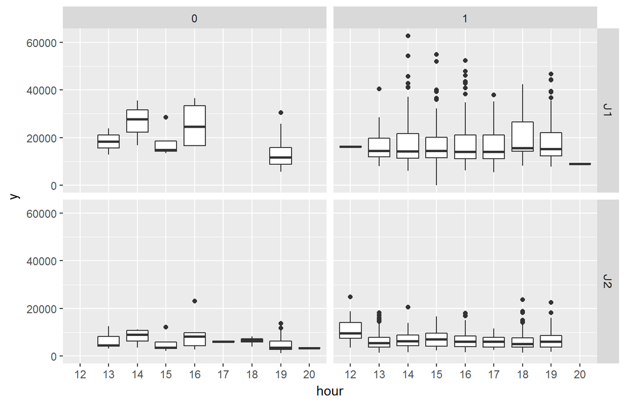

```r
ggplot(data = combi_time, mapping = aes(x = hour, y = y)) +
    geom_boxplot(aes(group = cut_width(hour,1))) +
    facet_grid(stage ~ week)
```

### 3.4.3 天候

雨の日が若干悪いがそれほど大差はない。

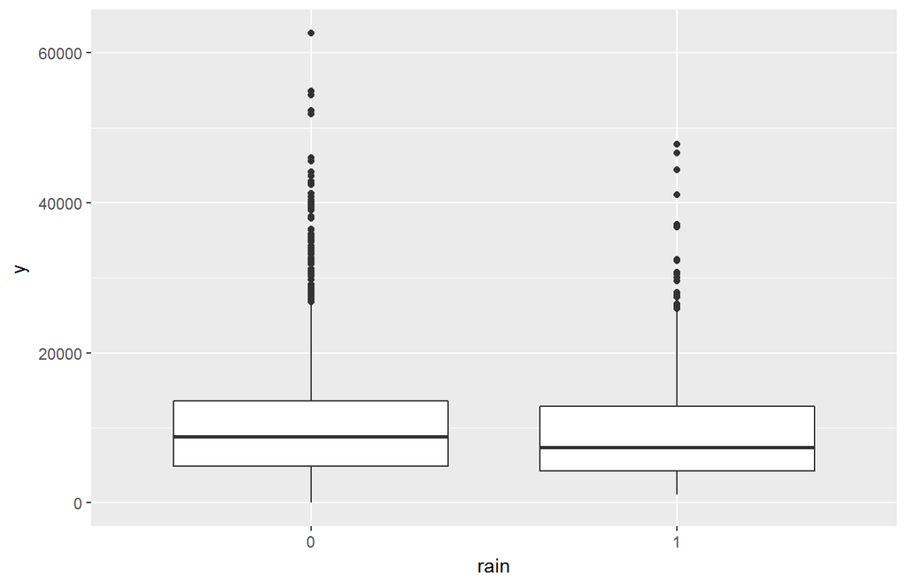

```r
combi_weather <- combi_time %>%
    dplyr::mutate(rain = as.factor(ifelse(str_detect(weather,"雨"), 1, 0)))

combi_weather %>%
    ggplot(mapping = aes(x = rain, y = y)) +
    geom_boxplot()
```

```r
combi_mod <- combi_weather
```

### 3.4.4 Spreadingで試合id毎のレコードにする(todo)

### 3.4.5 ランキングが接戦(near)の作成(todo)

### 3.4.6 残節数の減少にともなう下位争いの熱気(heat)の作成(todo)

## 3.5 trainとtestに分割する

```r
train <- combi_mod %>%
    dplyr::filter(!is.na(y))
test <- combi_mod %>%
    dplyr::filter(is.na(y))
```

# 4 Hold Outで検証

```r
## 構築データの割合
rate <- 0.7

## 構築データ数
num <- as.integer(nrow(train)*rate)

## 再現性のため乱数シードを固定
set.seed(17)

## sample(ベクトル, ランダムに取得する個数, 復元抽出の有無)
row<-sample(1:nrow(train), num, replace=FALSE)

## 構築データ
train_train <- train[row,]

## 検証データ
train_test <- train[-row,] %>%
    dplyr::filter(home_team != "カマタマーレ讃岐") %>%
    dplyr::filter(away_team != "カマタマーレ讃岐")
## カマタマーレ讃岐は2014からのチームなので、train_testから除外

###使用変数の作成
#変数選択(目的変数, 収容人数, 前節ランキング)
lm_train<-dplyr::select(train_train, y, param)
lm_test<-dplyr::select(train_test, param)

###重回帰分析
#family:目的変数の確率分布とリンク関数の設定(今回は正規分布と恒等写像)
lm<-glm(y ~ ., data=lm_train, family=gaussian(link="identity"))

### testに当てはめ
## type="response"でリンク関数を当てはめる前の値が返ってくる
pred<-predict(lm, lm_test, type="response")

## typeが無指定だとリンク関数を当てはめた値が返ってくる
## link="log"であれば, exp(pred)で予測値を返すことができる

## 結果出す前に、home,away分割を戻す
train_test$pred <- pred

result <- train_test %>%
    dplyr::group_by(id) %>%
    dplyr::summarise(
               y = mean(y),
               pred = mean(pred)
           )
## RMSEの計算
sqrt(mean((result$y - result$pred)^2))
```

```
## [1] 3574.5
```

# 5 OPT投稿データ作成

テストデータに追加ファイルを使用しているので、投稿対象の試合に絞る。

```r
## testデータにAddしたレコードを除去する。
sample <- read_csv("../motodata/sample_submit.csv", col_names=c("id","pred"))
nrow(sample)
```

```
## [1] 313
```

```r
nrow(test)
```

```
## [1] 351
```

```r
test <- test %>%
    dplyr::inner_join(sample %>% select(id), by="id")
nrow(test)
```

```
## [1] 313
```

```r
###使用変数の作成
#変数選択(目的変数, 収容人数, 前節ランキング)
lm_train<-dplyr::select(train, y, param)
lm_test<-dplyr::select(test, param)

###重回帰分析
#family:目的変数の確率分布とリンク関数の設定(今回は正規分布と恒等写像)
lm<-glm(y ~ ., data=lm_train, family=gaussian(link="identity"))

###testに当てはめ
#type="response"でリンク関数を当てはめる前の値が返ってくる
pred<-predict(lm, lm_test, type="response")

#typeが無指定だとリンク関数を当てはめた値が返ってくる
#link="log"であれば, exp(pred)で予測値を返すことができる

test$pred <- pred

###submit形式に整える
submit <- test %>%
    dplyr::select(c(id, pred))

str(submit)
```

```
## 'data.frame':    313 obs. of  2 variables:
##  $ id  : int  15822 15823 15824 15825 15827 15828 15829 15830 15831 15832 ...
##  $ pred: num  13518 17771 35206 12440 28406 ...
```

```r
## 残差確認
train$pred <- predict(lm, lm_train, type="response")

zan <- data.frame(train, Res=abs(train$y-train$pred), pred = train$pred, diff=train$y - train$pred) %>%
    dplyr::select(id, Res, y, pred, diff, stage, stadium, capa, temperature) %>%
    dplyr::arrange(desc(Res))

kable(head(zan %>% dplyr::filter(diff<=0), n=25))
```

| id | Res | y | pred | diff | stage | stadium | capa | temperature |
| --- | --- | --- | --- | --- | --- | --- | --- | --- |
| 15699 | 35015.541 | 0 | 35015.54 | -35015.541 | Ｊ１ | 埼玉スタジアム２００２ | 63700 | 16.2 |
| 15113 | 11680.775 | 17183 | 28863.77 | -11680.775 | Ｊ１ | 宮城スタジアム | 49133 | 10.4 |
| 14880 | 11302.162 | 23295 | 34597.16 | -11302.162 | Ｊ１ | 埼玉スタジアム２００２ | 63700 | 15.6 |
| 14982 | 10579.446 | 23725 | 34304.45 | -10579.446 | Ｊ１ | 埼玉スタジアム２００２ | 63700 | 24.1 |
| 14023 | 10231.796 | 25743 | 35974.80 | -10231.796 | Ｊ１ | 埼玉スタジアム２００２ | 63700 | 10.0 |
| 14026 | 10121.176 | 16836 | 26957.18 | -10121.176 | Ｊ１ | デンカビッグスワンスタジアム | 42300 | 7.1 |
| 14034 | 9929.807 | 15854 | 25783.81 | -9929.807 | Ｊ１ | デンカビッグスワンスタジアム | 42300 | 3.4 |
| 15669 | 9789.045 | 13809 | 23598.05 | -9789.045 | Ｊ１ | 国立競技場 | 54224 | 9.1 |
| 14022 | 9698.036 | 16229 | 25927.04 | -9698.036 | Ｊ１ | 味の素スタジアム | 49970 | 16.3 |
| 14256 | 9673.420 | 32090 | 41763.42 | -9673.420 | Ｊ１ | 埼玉スタジアム２００２ | 63700 | 20.1 |
| 14916 | 9025.765 | 24184 | 33209.77 | -9025.765 | Ｊ１ | 埼玉スタジアム２００２ | 63700 | 21.2 |
| 14859 | 8921.694 | 13702 | 22623.69 | -8921.694 | Ｊ１ | ヤンマースタジアム長居 | 47816 | 13.8 |
| 14970 | 8650.291 | 25638 | 34288.29 | -8650.291 | Ｊ１ | 埼玉スタジアム２００２ | 63700 | 29.4 |
| 15722 | 8157.297 | 26762 | 34919.30 | -8157.297 | Ｊ１ | 埼玉スタジアム２００２ | 63700 | 7.7 |
| 14873 | 8075.098 | 13859 | 21934.10 | -8075.098 | Ｊ１ | 味の素スタジアム | 49970 | 18.0 |
| 14864 | 8030.918 | 13721 | 21751.92 | -8030.918 | Ｊ１ | ヤンマースタジアム長居 | 47816 | 16.1 |
| 14157 | 8020.475 | 28142 | 36162.48 | -8020.475 | Ｊ１ | 埼玉スタジアム２００２ | 63700 | 31.3 |
| 14887 | 7908.167 | 13384 | 21292.17 | -7908.167 | Ｊ１ | ヤンマースタジアム長居 | 47816 | 13.3 |
| 14042 | 7848.960 | 25894 | 33742.96 | -7848.960 | Ｊ１ | 埼玉スタジアム２００２ | 63700 | 10.4 |
| 14855 | 7800.354 | 19195 | 26995.35 | -7800.354 | Ｊ１ | 日産スタジアム | 72327 | 17.5 |
| 15720 | 7625.823 | 14165 | 21790.82 | -7625.823 | Ｊ１ | 味の素スタジアム | 49970 | 10.0 |
| 14037 | 7468.285 | 12318 | 19786.28 | -7468.285 | Ｊ１ | エディオンスタジアム広島 | 50000 | 3.4 |
| 15724 | 7406.376 | 19181 | 26587.38 | -7406.376 | Ｊ１ | 日産スタジアム | 72327 | 18.4 |
| 14839 | 7274.859 | 15051 | 22325.86 | -7274.859 | Ｊ１ | ヤンマースタジアム長居 | 47816 | 6.6 |
| 15712 | 7036.296 | 12174 | 19210.30 | -7036.296 | Ｊ１ | ノエビアスタジアム神戸 | 30132 | 17.7 |

```r
###CSV出力(ヘッダーなし)
write.table(submit, file="../submit/submit_20171124_1_lm.csv",
            quote=FALSE, sep=",", row.names=FALSE, col.names=FALSE)
```

# 6 データの考察

## 6.1 前節ランキング(pre_rank)は観客動員数(y)と相関があるのか？

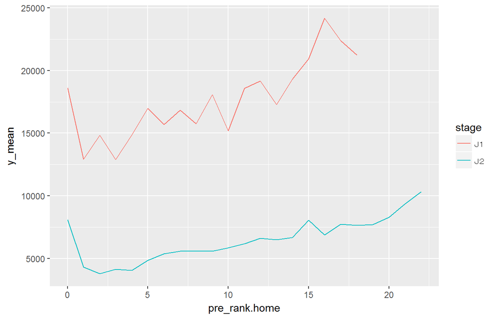

```r
train %>%
    dplyr::group_by(stage, pre_rank.home) %>%
    dplyr::summarise(y_mean = mean(y)) %>%
    dplyr::ungroup(.) %>%
    ggplot(., mapping=aes(x = pre_rank.home, y = y_mean)) + geom_line(mapping = aes(colour = stage))
```

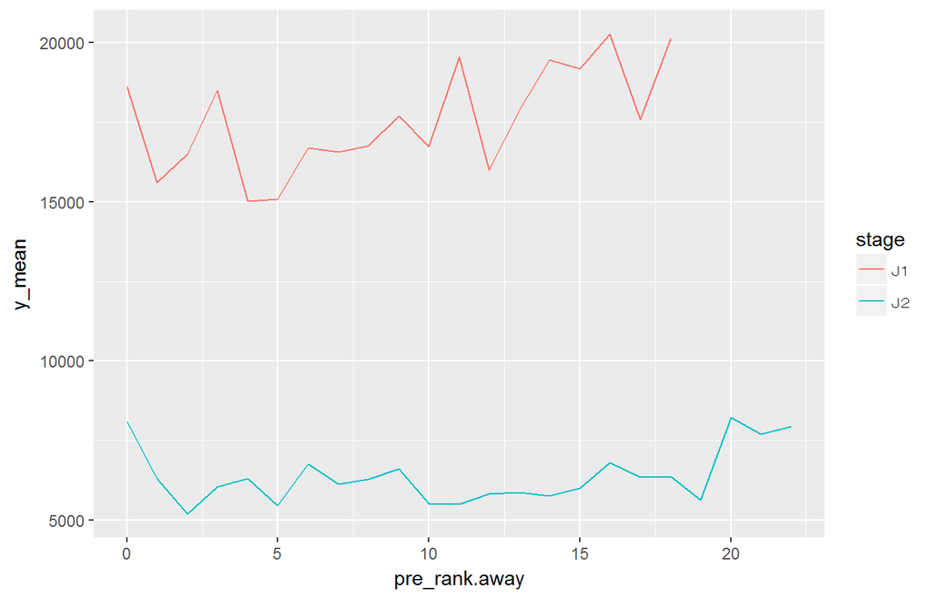

```r
train %>%
    dplyr::group_by(stage, pre_rank.away) %>%
    dplyr::summarise(y_mean = mean(y)) %>%
    dplyr::ungroup(.) %>%
    ggplot(., mapping=aes(x = pre_rank.away, y = y_mean)) + geom_line(mapping = aes(colour = stage))
```

## 6.2 対戦するチームの組合せによって集客が変わるのか？

年で若干異なる。傾向の有無までは判断できず。

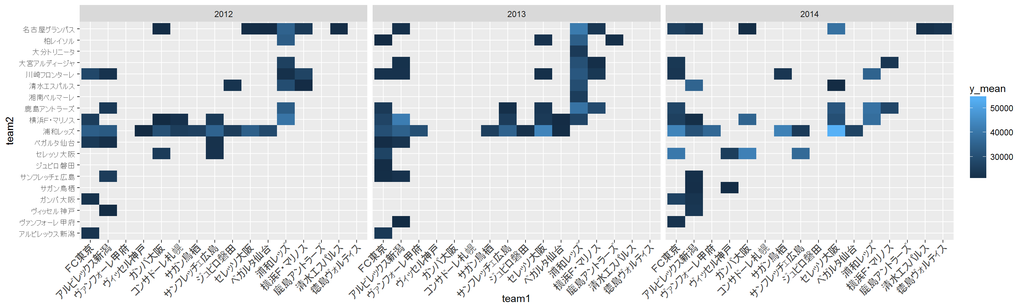

```r
train %>%
    dplyr::filter(stage == "Ｊ１") %>%
    dplyr::mutate(team1 = if_else(home_team < away_team, home_team, away_team),
                  team2 = if_else(home_team > away_team, home_team, away_team)) %>%
    dplyr::group_by(year, team1, team2) %>%
    dplyr::summarise(y_mean = mean(y)) %>%
    dplyr::ungroup(.) %>%
    dplyr::filter(y_mean > 20000) %>%
    ggplot(mapping=aes(x = team1, y = team2)) +
    geom_tile(mapping = aes(fill=y_mean)) +
    facet_grid(. ~ year) +
    theme(axis.text.x = element_text(angle = 45, hjust = 1))
```